# dados de microssatélite de isolados de *C. parapsilosis*

Luiza Souza Rodrigues e [Henrique Laureano](https://henriquelaureano.github.io/)

Last modification on* 2022-08-08 17:01:58

# Reduzido 08/08/2022

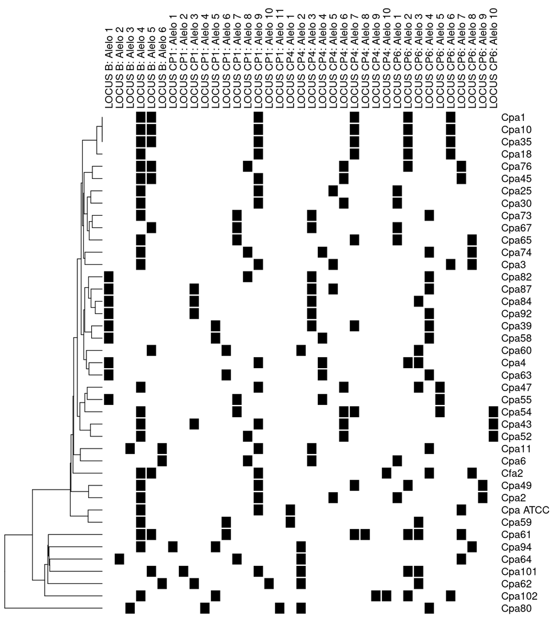

> As dissimilaridades são apresentadas de maneira sequencial, sempre referente a amostra de cima e começando da primeira linha do gráfico acima.
> - `Cpa10` tem zero dissimilaridade com `Cpa1` (então, similaridade de 100%);
> - `Cpa35` tem zero dissimilaridade com `Cpa10`;
> - **Ou seja, `Cpa1`; `Cpa10` e `Cpa35` formam um cluster com similaridade de 100%**;
> - `Cpa18` tem 3.18% de dissimilaridade com `Cpa35` (e consequentemente de todos os elementos de seu cluster);
> - `Cpa76` tem 11.61% de dissimilaridade com `Cpa18`;
> - `Cpa45` tem 5.78% de dissimilaridade com `Cpa76`;

> E assim por diante.

```
     sample dissimilarity
1      Cpa1            NA
2     Cpa10      0.000000
3     Cpa35      0.000000
4     Cpa18      3.181247
5     Cpa76     11.606538
6     Cpa45      5.779153
7     Cpa25     10.670829
8     Cpa30      6.687543
9     Cpa73      8.769127
10    Cpa67      5.839607
11    Cpa65      7.629652
12    Cpa74     10.948208
13     Cpa3     10.129609
14    Cpa82     12.369577
```

[output cut: 27 more lines]

# 08/08/2022

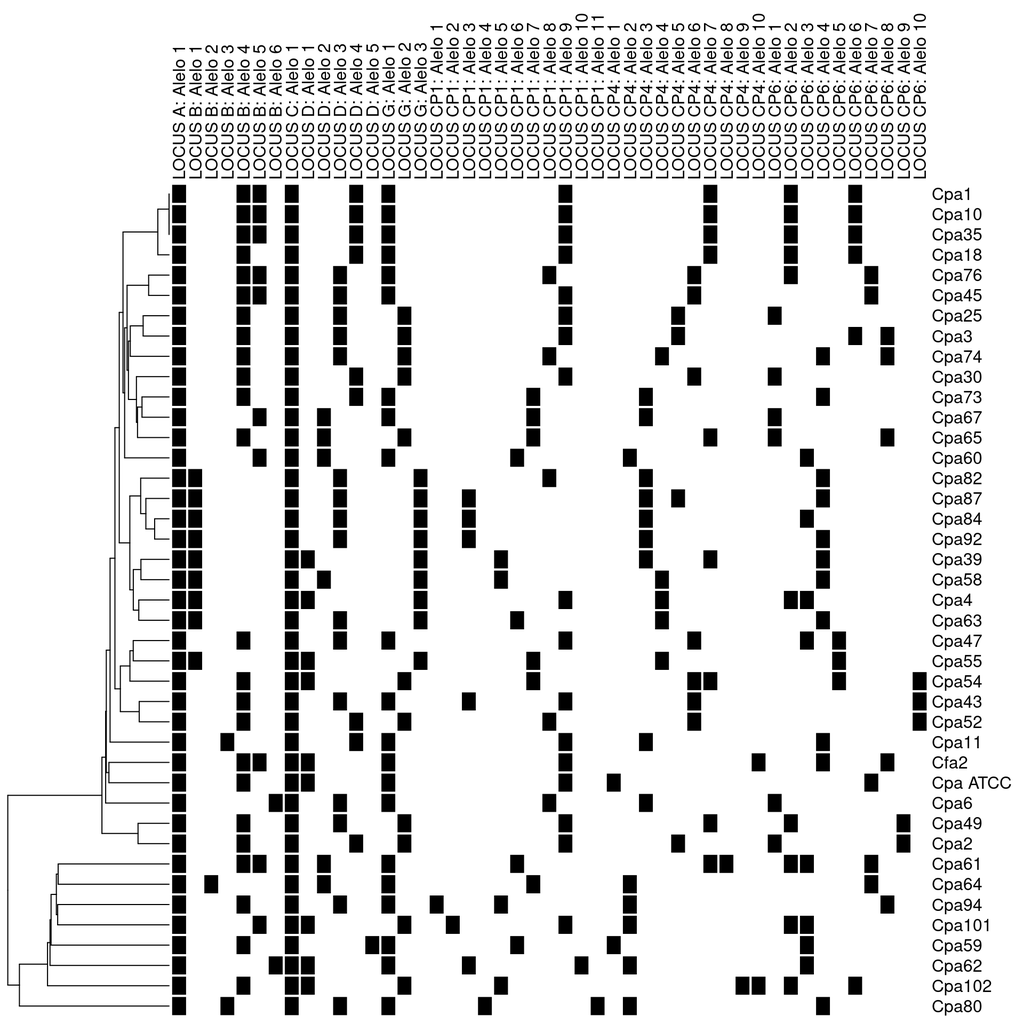

> As dissimilaridades são apresentadas de maneira sequencial, sempre referente a amostra de cima e começando da primeira linha do gráfico acima.
> - `Cpa10` tem zero dissimilaridade com `Cpa1` (então, similaridade de 100%);
> - `Cpa35` tem zero dissimilaridade com `Cpa10`;
> - **Ou seja, `Cpa1`; `Cpa10` e `Cpa35` formam um cluster com similaridade de 100%**;
> - `Cpa18` tem 3.25% de dissimilaridade com `Cpa35` (e consequentemente de todos os elementos de seu cluster);
> - `Cpa76` tem 13.32% de dissimilaridade com `Cpa18`;
> - `Cpa45` tem 5.91% de dissimilaridade com `Cpa76`;

> E assim por diante.

```
     sample dissimilarity
1      Cpa1            NA
2     Cpa10      0.000000
3     Cpa35      0.000000
4     Cpa18      3.251173
5     Cpa76     13.320269
6     Cpa45      5.906182
7     Cpa25     12.144947
8      Cpa3      7.498986
9     Cpa74     11.213417
10    Cpa30     11.744971
11    Cpa73      9.436751
12    Cpa67      7.825805
13    Cpa65      9.122749
14    Cpa60     12.850415
```

[output cut: 27 more lines]

# Referências

> A análise estatística foi realizada no ambiente de computação estatística `R` (R Core Team, 2022). Os principais pacotes `R` utilizados foram o {`readxl`} (Wickham & Bryan, 2022), {`tidyr`} (Wickham & Girlich, 2022), {`dplyr`} (Wickham et al., 2022), {`ComplexHeatmap`} (Gu, 2016) e {`cluster`} (Maechler et al., 2022).

> Para clusterização utilizamos a rotina `agnes` (Agglomerative Nesting - Hierarchical Clustering), baseada numa generalização do algoritmo UPGMA (Kaufman & Rousseeuw, 1990; Belbin et al., 1992).

> R Core Team (2022). R: A language and environment for statistical computing. R Foundation for Statistical Computing, Vienna, Austria. URL https://www.R-project.org/

> Wickham, H., Bryan, J. (2022). readxl: Read Excel Files. R package version 1.4.0, https://CRAN.R-project.org/package=readxl

> Wickham, H., Girlich, M. (2022). tidyr: Tidy Messy Data. R package version 1.2.0, https://CRAN.R-project.org/package=tidyr

> Wickham, H., François, R., Henry, L., Müller, K. (2022). dplyr: A Grammar of Data Manipulation. R package version 1.0.9. https://CRAN.R-project.org/package=dplyr

> Gu, Z. (2016). Complex heatmaps reveal patterns and correlations in multidimensional genomic data. Bioinformatics. https://doi.org/10.1093/bioinformatics/btw313

> Maechler, M., Rousseeuw, P., Struyf, A., Hubert, M., Hornik, K. (2022). cluster: Cluster Analysis Basics and Extensions. R package version 2.1.3

> Kaufman, L. Rousseeuw, P. J. (1990). Finding Groups in Data: An Introduction to Cluster Analysis. Wiley, New York

> Belbin, L., Faith, D. P., Milligan, G. W. (1992). A Comparison of Two Approaches to Beta-Flexible Clustering. Multivariate Behavioral Research, *27*, 417-433